# datacamp_TS4_AutoRegressiveModels

## Simple forecasts from an estimated AR model

Now that you’ve **modeled your data** using the arima() command, you are ready to make simple forecasts based on your model. The predict() function can be used **to make forecasts from an estimated AR model**. In the object generated by your predict() command:

- $pred value is the forecast, and
- $se value is the standard error for the forceast.

To make predictions for several periods beyond the last observations, you can use the **n.ahead** argument in your predict() command. This argument establishes the **forecast horizon (h)**, or the number of periods being forecast. The forecasts are made recursively from 1 to h-steps ahead from the end of the observed time series.

In this exercise, you’ll make simple forecasts using an AR model applied to the Nile data, which records annual observations of the flow of the River Nile from 1871 to 1970.

```r
# Fit an AR model to Nile
AR_fit <-arima(Nile, order  = c(1,0,0))
print(AR_fit)
```

```
##
## Call:
## arima(x = Nile, order = c(1, 0, 0))
##
## Coefficients:
##          ar1  intercept
##       0.5063   919.5685
## s.e.  0.0867    29.1410
##
## sigma^2 estimated as 21125:  log likelihood = -639.95,  aic = 1285.9
```

```r
# Use predict() to make a 1-step forecast
predict_AR <- predict(AR_fit)

# Obtain the 1-step forecast using $pred[1]

predict_AR$pred[1]
```

```
## [1] 828.6576
```

```r
# Use predict to make 1-step through 10-step forecasts
predict(AR_fit, n.ahead = 10)
```

```
## $pred
## Time Series:
## Start = 1971
## End = 1980
## Frequency = 1
##  [1] 828.6576 873.5426 896.2668 907.7715 913.5960 916.5448 918.0377
##  [8] 918.7935 919.1762 919.3699
##
## $se
## Time Series:
## Start = 1971
## End = 1980
## Frequency = 1
##  [1] 145.3439 162.9092 167.1145 168.1754 168.4463 168.5156 168.5334
##  [8] 168.5380 168.5391 168.5394
```

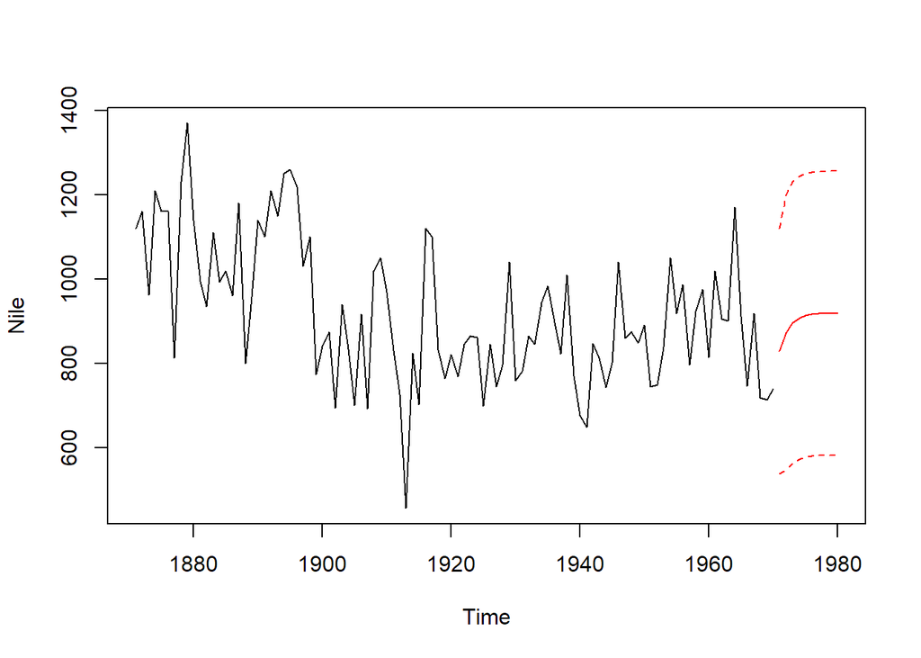

```r
# Run to plot the Nile series plus the forecast and 95% prediction intervals
ts.plot(Nile, xlim = c(1871, 1980))
AR_forecast <- predict(AR_fit, n.ahead = 10)$pred
AR_forecast_se <- predict(AR_fit, n.ahead = 10)$se
points(AR_forecast, type = "l", col = 2)
points(AR_forecast - 2*AR_forecast_se, type = "l", col = 2, lty = 2)
points(AR_forecast + 2*AR_forecast_se, type = "l", col = 2, lty = 2)
```